# FM17 误判诊断：三轮迭代与改进建议

本次完成三轮探索，正式 FM-1.7.0 与原冻结预测保持不变。样本为26098、26101、26102：346场预测、345场已结算，T−24同场214场。26098#102取消不计分，#135缺明确截止未估算；未补造26099/26100。案例按已知赛果筛选，候选方案也是已知结果后的探索，不构成独立前瞻验证，不能据此宣布升级胜出。

```r
suppressPackageStartupMessages(library(tidyverse))
root <- normalizePath('..')
out <- file.path(root,'results/fm17-diagnostic-iterations-20261013')
library(beidan,lib.loc=file.path(out,'library'))
inv <- jsonlite::fromJSON(file.path(out,'delivery-inventory.json'))
for(i in seq_len(nrow(inv$files))) stopifnot(digest::digest(file=file.path(root,inv$files$path[i]),algo='sha256')==inv$files$sha256[i])
Sys.setenv(RETICULATE_PYTHON=file.path(root,'.venv/bin/python'))
r1 <- jsonlite::fromJSON(file.path(out,'round1-receipt.json'))
for(i in seq_len(nrow(r1$inputs))) stopifnot(digest::digest(file=file.path(root,r1$inputs$path[i]),algo='sha256')==r1$inputs$sha256[i])
for(i in seq_len(nrow(r1$outputs))) stopifnot(digest::digest(file=file.path(out,r1$outputs$path[i]),algo='sha256')==r1$outputs$sha256[i])
stopifnot(digest::digest(file=file.path(root,'r/fm17_diagnostic_round1.R'),algo='sha256')==r1$client_sha256)
nr <- jsonlite::fromJSON(file.path(out,'case-notes-receipt.json'))
stopifnot(digest::digest(file=file.path(out,'case-notes.csv'),algo='sha256')==nr$notes_sha256,
 digest::digest(file=file.path(root,'r/fm17_diagnostic_case_notes.R'),algo='sha256')==nr$client_sha256,
 nr$source_case_sha256==r1$outputs$sha256[r1$outputs$path=='round1-cases.rds'])
for (f in c('round2-evaluation.json','round3-evaluation.json')) {
  e <- jsonlite::fromJSON(file.path(out,f))
  cl <- if(f=='round2-evaluation.json') 'r/fm17_diagnostic_round2_evaluate.R' else 'r/fm17_diagnostic_round3_evaluate.R'
  stopifnot(digest::digest(file=file.path(root,cl),algo='sha256')==e$client_sha256)
  for(i in seq_len(nrow(e$outputs))) stopifnot(digest::digest(file=file.path(out,e$outputs$path[i]),algo='sha256')==e$outputs$sha256[i])
}
rp2 <- jsonlite::fromJSON(file.path(out,'round2-replay.json'))
rpn <- jsonlite::fromJSON(file.path(out,'round3-native-replay.json'))
rpp <- jsonlite::fromJSON(file.path(out,'round3-partial-replay.json'))
stopifnot(rp2$status=='FULL_IDENTICAL_REPLAY',rpn$status=='FULL_IDENTICAL_REPLAY',rpp$status=='FULL_IDENTICAL_REPLAY')
for (pair in list(c('round2-forecasts.rds',rp2$sha256),c('round3-native-forecasts.rds',rpn$sha256),c('round3-partial-forecasts.rds',rpp$sha256))) {
  stopifnot(digest::digest(file=file.path(out,pair[1]),algo='sha256')==pair[2])
}
a <- read_csv(file.path(out,'round2-metrics.csv'),show_col_types=FALSE)
b <- read_csv(file.path(out,'round3-metrics.csv'),show_col_types=FALSE)
notes <- read_csv(file.path(out,'case-notes.csv'),show_col_types=FALSE)
```

## 第一轮：先区分来源问题和保护排序问题

北单Top1正确而FM17 Top2未覆盖的7场中，6场使用原生λ；117场原生来源里，64场冻结快照没有欧赔/亚盘/大小球，另39场三通道可计算但没有被完整市场一致性流程采用。快照缺失不等于当时没有盘口，优先检查采集覆盖、公司篮子、身份和时间，而不是直接追随北单SP。

不压尾Top2正确而压尾遗漏的13场，最终第二、第三选择差距均不超过2.55个百分点。单一实际净胜球落在核心里也不保证北单整类概率增加：让胜或让负包含多个净胜球档，外围被压缩可能降低整类质量。这是排名边界问题，不能只盯实际比分所在一档。

```r
knitr::kable(read_csv(file.path(out,'round1-summary.csv'),show_col_types=FALSE),digits=4)
```

| issue_id | selected_source | n | bd1_fm1_loss | bd1_fm2_loss | raw1_tail_loss | raw2_tail_loss | reversed_direction | actual_outside_core | mean_delta_ll_bd | mean_delta_ll_tail |
| --- | --- | --- | --- | --- | --- | --- | --- | --- | --- | --- |
| 26098 | market | 101 | 7 | 1 | 1 | 2 | 26 | 7 | 0.0019 | -0.0069 |
| 26098 | native | 43 | 7 | 1 | 0 | 1 | 12 | 1 | -0.0030 | 0.0055 |
| 26101 | market | 65 | 0 | 0 | 1 | 4 | 8 | 4 | -0.0492 | -0.0055 |
| 26101 | native | 50 | 7 | 2 | 1 | 3 | 17 | 5 | 0.1303 | -0.0014 |
| 26102 | market | 62 | 3 | 0 | 0 | 1 | 10 | 9 | 0.0098 | 0.0054 |
| 26102 | native | 24 | 8 | 3 | 0 | 2 | 5 | 3 | 0.0711 | 0.0119 |

```r
knitr::kable(notes,caption='人工逐场事实复核：ROOT_CODEX；未使用PA，不虚构外部阵容、排名或JEV证据')
```

人工逐场事实复核：ROOT_CODEX；未使用PA，不虚构外部阵容、排名或JEV证据

| fixture_id | mechanism | evidence | counterevidence | next_action |
| --- | --- | --- | --- | --- |
| 26102:6 | 原生与盘口方向冲突 | 原生λ1.11/1.56；已观测主让0.5同价及大小球，仅欧赔缺失使完整市场反解未执行；三档α都保持客队λ更高。 | 单公司部分盘口、已知主胜均不能证明可推广的校准优势。 | 优先补欧赔；AH+OU分层反解作为影子模型，来源准入仍需独立一致性审查。 |
| 26101:98 | 净胜深度与盘口缺失 | 北单主受让1：客赢2+类概率由约17.5%降至14.3%，尽管实际净胜-2仍在核心；快照三通道全缺。 | 客赢2球可以是合理低概率事件；没有独立亚盘或已核验评级支持强行上调客队。 | 补同截止独立价格和对手强度；原生不确定性优先，α仅做固定敏感性。 |
| 26101:5 | 杯赛样本可比性 | 杯赛原生λ1.68/1.55，来自分开平均的主客攻防，未校正对手；无冻结盘口；高让球类别概率不等于普通胜负实力确定。 | 球队级别、阵容伤停未独立核验，实际输球不足以证明实力估计必错。 | 补历史对手/比赛级别/阵容证据，原生不确定时先验证是否应停止尖化分布。 |
| 26101:8 | 杯赛样本可比性 | 杯赛原生λ1.46/1.05、无冻结盘口；客队近期进失球不同于长期，且未调对手强度。 | 根据本场赛果选α会过拟合；近期变动也可能来自对手构成。 | 对手强度进入原生攻防环节；保留成功原生反例，做此前窗口的逐期验证。 |
| 26101:103 | 近并列保护与低覆盖篮子 | 三通道可算但欧赔只有一家；普通欧赔主36.4%/客35.7%接近平衡；实际客胜类32.0%降到30.2%，保护差0.65个百分点。 | 欧赔本身不支持客队明显优势，平手亚盘略偏主；客胜不是强客证据。 | 报告保护不稳定，补独立公司篮子，不按赛果强制把客队λ调高。 |
| 26102:74 | 欧亚有记录但大小球缺失 | 欧赔主34.8%/客37.8%，平手亚盘客侧价格更低；原生1.32/1.18偏主；OU缺失阻断联合来源，保护差0.82个百分点。 | 市场优势轻微，单公司亚盘且总量不明，无法确认净胜深度。 | 补OU；对假设总量做有界部分市场敏感性，并提示保护不稳定。 |
| 26102:73 | 普通方向正确但胜差不足 | 主让1投影；欧赔主胜57.2%；原生1.48/0.99同样偏主，但实际净胜4在90%核心外，赢2+整类被削减，亚盘缺失。 | 大胜也可能是尾部实现；无让球欧赔不能单独证明大胜预期。 | 补亚盘；普通方向与净胜深度分开，不用北单-1反调λ。 |
| 26098:137 | 市场未预期的单次实现 | 完整市场来源，普通主胜仅微弱领先；客胜类原约29.6%、压尾29.2%，尾部惩罚很小。 | 客赢3不能成为赛后翻转被接受市场定价的理由。 | 若无截止前阵容/战意证据反对原来源，先视为结果波动，不逐场拟合。 |
| 26098:21 | 核心单档与整类质量不同 | 完整市场来源；实际客赢2在核心，客胜整类仍由29.6%降至28.0%，保护差0.70个百分点。 | 原生与市场普通客胜均非最高；停止市场压尾会丢掉许多其他成功样本。 | 展示预测期内排序敏感性及前后视图，拒绝普遍停用市场压尾。 |
| 26101:56 | 核心单档与整类质量不同 | 主让1；实际主赢3在核心，但赢2+整类25.9%降至24.4%，保护差0.78个百分点；无冻结盘口。 | 是否保留核心不能依据已知净胜球，实际在核心也不能新设阈值。 | 保留完整让球类别汇总；原生不压尾仅列待验证候选。 |
| 26098:36 | 主选近并列反例 | 市场来源；FM16主选正确而FM17错，需看净胜分布位置和整类质量，而非单档众数。 | FM17相对FM16总体仍有正收益，这只是四场主选损失之一。 | 同时列改善与损失、校正前后差距，不为希望的角色搬运质量。 |
| 26101:82 | 成功原生对照 | 原生FM17在本场优于北单，作为原生质量诊断的成功对照保留。 | 单场成功同样不能证明原生模型普遍可靠。 | 不一律剔除原生，以可观测来源质量和稳定性评价。 |
| 26102:24 | 成功青年赛对照 | 青年赛且冻结欧赔缺失，原生预测命中而北单错，保留为对照。 | 青年队获胜不能验证跨届、跨对手样本可比。 | 核验年龄/阵容连续性及对手强度，不按青年赛标签一刀切拒绝。 |

## 第二轮：固定压尾候选与来源消融

固定测试90%核心/0.6外部系数、95%核心/0.3外部系数，以及只保留市场或原生来源的不压尾组件。没有按目标结果搜索参数。Brier为三类平方误差之和，log loss用自然对数，两者越低越好。

```r
knitr::kable(a |> filter(issue_id=='ALL',cohort=='all') |> select(comparison,model,n,hits1,hits2,brier,logloss),digits=6)
```

| comparison | model | n | hits1 | hits2 | brier | logloss |
| --- | --- | --- | --- | --- | --- | --- |
| same_cutoff | C90_COEF60 | 214 | 81 | 148 | 0.683940 | 1.122800 |
| same_cutoff | C95_COEF30 | 214 | 79 | 144 | 0.684383 | 1.123415 |
| same_cutoff | FM-1.7.0 | 214 | 81 | 150 | 0.683462 | 1.121824 |
| same_cutoff | FM17-source-before-tail | 214 | 80 | 143 | 0.684848 | 1.124691 |
| same_cutoff | MARKET_RETAIN | 214 | 79 | 141 | 0.686901 | 1.127911 |
| same_cutoff | NATIVE_RETAIN | 214 | 82 | 152 | 0.681409 | 1.118605 |
| same_cutoff | 北单-T24 | 214 | 71 | 149 | 0.780005 | 1.342765 |
| same_cutoff | FM-1.6.0 | 214 | 80 | 151 | 0.687068 | 1.125768 |
| near_sale | C90_COEF60 | 345 | 131 | 249 | 0.683100 | 1.120260 |
| near_sale | C95_COEF30 | 345 | 129 | 243 | 0.683057 | 1.120341 |
| near_sale | FM-1.7.0 | 345 | 131 | 250 | 0.683364 | 1.120218 |
| near_sale | FM17-source-before-tail | 345 | 129 | 244 | 0.683083 | 1.120975 |
| near_sale | MARKET_RETAIN | 345 | 128 | 243 | 0.684491 | 1.122294 |
| near_sale | NATIVE_RETAIN | 345 | 132 | 251 | 0.681956 | 1.118899 |
| near_sale | 北单-后期SP | 345 | 130 | 244 | 0.670167 | 1.103727 |
| near_sale | FM-1.6.0 | 345 | 129 | 247 | 0.686963 | 1.124016 |

```r
knitr::kable(a |> filter(issue_id!='ALL',cohort=='all',model %in% c('FM-1.7.0','NATIVE_RETAIN')) |> select(issue_id,comparison,model,n,hits1,hits2,brier,logloss),digits=6)
```

| issue_id | comparison | model | n | hits1 | hits2 | brier | logloss |
| --- | --- | --- | --- | --- | --- | --- | --- |
| 26098 | same_cutoff | FM-1.7.0 | 105 | 42 | 75 | 0.660731 | 1.090628 |
| 26098 | same_cutoff | NATIVE_RETAIN | 105 | 42 | 75 | 0.661147 | 1.090992 |
| 26101 | same_cutoff | FM-1.7.0 | 89 | 32 | 62 | 0.707467 | 1.154544 |
| 26101 | same_cutoff | NATIVE_RETAIN | 89 | 33 | 63 | 0.704206 | 1.149851 |
| 26102 | same_cutoff | FM-1.7.0 | 20 | 7 | 13 | 0.695971 | 1.140005 |
| 26102 | same_cutoff | NATIVE_RETAIN | 20 | 7 | 14 | 0.686337 | 1.124524 |
| 26098 | near_sale | FM-1.7.0 | 144 | 56 | 102 | 0.661773 | 1.093062 |
| 26098 | near_sale | NATIVE_RETAIN | 144 | 56 | 102 | 0.660936 | 1.091408 |
| 26101 | near_sale | FM-1.7.0 | 115 | 42 | 83 | 0.727588 | 1.178635 |
| 26101 | near_sale | NATIVE_RETAIN | 115 | 43 | 84 | 0.725754 | 1.179226 |
| 26102 | near_sale | FM-1.7.0 | 86 | 33 | 65 | 0.660377 | 1.087573 |
| 26102 | near_sale | NATIVE_RETAIN | 86 | 33 | 65 | 0.658586 | 1.084262 |

全局放松系数或扩大核心没有稳定收益。仅原生来源暂不压尾，较晚SP同场由131/250提高到132/251，T−24由81/150到82/152，但收益小且集中，26101的log loss还略差，不能马上推广为正式规则。它适合作为“证据不确定时是否暂停压尾”的预先冻结候选；裁决应基于数据质量，不能只凭与市场不一致倒推置信度。

预测内不压尾/压尾Top2集合变化共有51场：13次覆盖损失、19次收益、19次共同覆盖。因此它是稳定性提示，不是误判报警，不能全部剔除，也不能人为改概率确保Top2；三选还须比较同预算策略成本与收益。

## 第三轮：原生近期权重与部分盘口约束

117场原生λ在原明确截止的先前历史上重拟合近期混合权重0.25/0.5/0.75；0.5完全复现原参数和概率。近期与长期分别归一化，使用共享时间模块、权重账本、ESS与长期收缩。没有根据目标赛果选最佳权重。0.75多两个Top1，但总体log loss变差，26098表现退化，不采用全局调整。

有半球亚盘且大小球至少2.5的60场，试验固定ρ=-0.1的AH+OU单公司影子反解；其中59场可计分（取消场剔除），包括50个原市场来源控制和9个原生来源。只支持半球无走盘，不能代表整数、四分之一盘口或完整多公司市场准入。

```r
knitr::kable(b |> filter(issue_id=='ALL',cohort=='all') |> select(experiment,comparison,model,n,hits1,hits2,brier,logloss),digits=6)
```

| experiment | comparison | model | n | hits1 | hits2 | brier | logloss |
| --- | --- | --- | --- | --- | --- | --- | --- |
| native | same_cutoff | FM-1.7.0 | 85 | 23 | 56 | 0.743578 | 1.204690 |
| native | same_cutoff | FM17-source-before-tail | 85 | 24 | 58 | 0.738410 | 1.196584 |
| native | same_cutoff | NATIVE_ALPHA_25 | 85 | 22 | 54 | 0.746147 | 1.209128 |
| native | same_cutoff | NATIVE_ALPHA_50 | 85 | 23 | 56 | 0.743578 | 1.204690 |
| native | same_cutoff | NATIVE_ALPHA_75 | 85 | 25 | 60 | 0.743959 | 1.205972 |
| native | same_cutoff | 北单-T24 | 85 | 26 | 59 | 0.772665 | 1.302601 |
| native | near_sale | FM-1.7.0 | 117 | 33 | 85 | 0.741087 | 1.196245 |
| native | near_sale | FM17-source-before-tail | 117 | 34 | 86 | 0.736938 | 1.192357 |
| native | near_sale | NATIVE_ALPHA_25 | 117 | 31 | 82 | 0.743972 | 1.198976 |
| native | near_sale | NATIVE_ALPHA_50 | 117 | 33 | 85 | 0.741087 | 1.196245 |
| native | near_sale | NATIVE_ALPHA_75 | 117 | 35 | 86 | 0.740542 | 1.198376 |
| native | near_sale | 北单-后期SP | 117 | 42 | 79 | 0.687294 | 1.127084 |
| partial | same_cutoff | FM-1.7.0 | 35 | 16 | 26 | 0.636638 | 1.051761 |
| partial | same_cutoff | FM17-source-before-tail | 35 | 16 | 25 | 0.641963 | 1.064892 |
| partial | same_cutoff | HALF_AH_OU_RAW | 35 | 16 | 24 | 0.646031 | 1.071545 |
| partial | same_cutoff | HALF_AH_OU_TAIL | 35 | 16 | 25 | 0.639873 | 1.058474 |
| partial | same_cutoff | 北单-T24 | 35 | 15 | 26 | 0.810469 | 1.374438 |
| partial | near_sale | FM-1.7.0 | 59 | 26 | 41 | 0.647198 | 1.068569 |
| partial | near_sale | FM17-source-before-tail | 59 | 26 | 41 | 0.650881 | 1.078711 |
| partial | near_sale | HALF_AH_OU_RAW | 59 | 27 | 39 | 0.649511 | 1.077446 |
| partial | near_sale | HALF_AH_OU_TAIL | 59 | 27 | 41 | 0.645412 | 1.067340 |
| partial | near_sale | 北单-后期SP | 59 | 27 | 45 | 0.635943 | 1.051782 |

26102#6原生λ为1.11/1.56，三种近期权重均保持客强；同截止主让0.5两侧1.90、大小球2.5两侧1.88/1.93，影子反解λ约1.646/1.055，总进球2.701，原始主胜50%、平26.86%、客胜23.14%。这是盘口与原生方向的真实冲突，不是压尾或简单增加近期权重能修复的。仍需复核来源身份、主客和符号；缺欧赔不能伪造欧赔参与模型。

9场原生影子样本Top1由2到3，Top2仍6；59场整体Top1由26到27，Top2仍41。证据不足正式准入，先作为影子层保存。完整市场控制下去掉欧赔可能损失保护，不能用部分约束替换完整渠道。

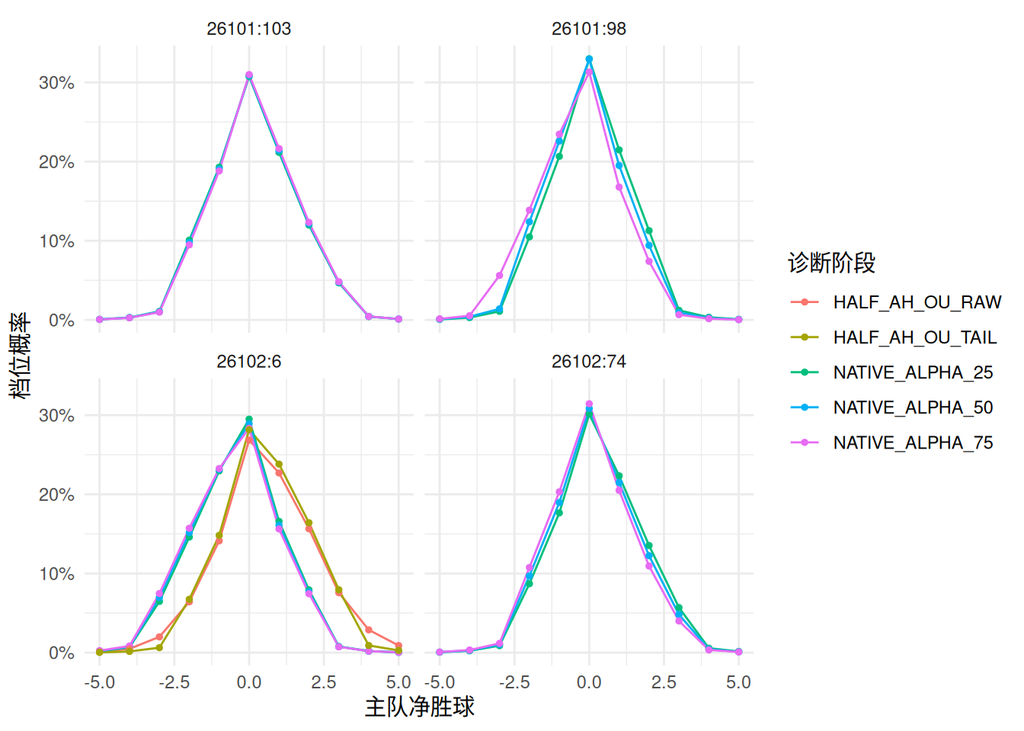

```r
margins <- read_csv(file.path(out,'round3-case-margins.csv'),show_col_types=FALSE)
margins |> filter(fixture_id %in% c('26102:6','26101:98','26101:103','26102:74'),between(margin,-5,5)) |>
 ggplot(aes(margin,probability,color=stage)) + geom_line() + geom_point(size=1) + facet_wrap(~fixture_id) +
 scale_y_continuous(labels=scales::percent) + labs(x='主队净胜球',y='档位概率',color='诊断阶段') + theme_minimal()
```

```r
knitr::kable(read_csv(file.path(out,'round3-native-stability.csv'),show_col_types=FALSE),digits=4)
```

| fixture_id | lambda_diff_min | lambda_diff_max | direction_flips | top1_changes | top2_changes |
| --- | --- | --- | --- | --- | --- |
| 26098:10 | 0.2194 | 0.6565 | FALSE | FALSE | FALSE |
| 26098:101 | 0.1937 | 0.3146 | FALSE | FALSE | FALSE |
| 26098:114 | 0.8542 | 1.0625 | FALSE | TRUE | FALSE |
| 26098:115 | -0.1561 | -0.0932 | FALSE | FALSE | FALSE |
| 26098:118 | -0.1760 | 0.0969 | TRUE | TRUE | FALSE |
| 26098:127 | 0.3594 | 0.4531 | FALSE | FALSE | TRUE |
| 26098:13 | -1.0615 | -0.8094 | FALSE | TRUE | FALSE |
| 26098:132 | 0.4750 | 0.4917 | FALSE | FALSE | FALSE |
| 26098:138 | 0.0249 | 0.0746 | FALSE | FALSE | FALSE |
| 26098:140 | 0.1594 | 0.3448 | FALSE | FALSE | FALSE |
| 26098:16 | -0.7125 | -0.6375 | FALSE | FALSE | FALSE |
| 26098:2 | 1.2500 | 1.5000 | FALSE | FALSE | FALSE |
| 26098:23 | 0.5179 | 0.5536 | FALSE | FALSE | FALSE |
| 26098:27 | -0.0875 | 0.2375 | TRUE | TRUE | TRUE |
| 26098:28 | 0.0677 | 0.1892 | FALSE | FALSE | TRUE |
| 26098:29 | 0.8333 | 1.0000 | FALSE | FALSE | FALSE |
| 26098:30 | 0.6333 | 0.6500 | FALSE | FALSE | FALSE |
| 26098:35 | -0.0510 | -0.0281 | FALSE | FALSE | FALSE |
| 26098:37 | 0.6281 | 0.9177 | FALSE | FALSE | FALSE |
| 26098:40 | 0.2483 | 0.7911 | FALSE | FALSE | TRUE |
| 26098:42 | 0.0875 | 0.1958 | FALSE | FALSE | TRUE |
| 26098:43 | 0.0156 | 0.0469 | FALSE | FALSE | FALSE |
| 26098:44 | 0.5562 | 0.7688 | FALSE | FALSE | FALSE |
| 26098:45 | 0.3639 | 0.5380 | FALSE | FALSE | FALSE |
| 26098:47 | 0.2250 | 0.2417 | FALSE | FALSE | FALSE |
| 26098:48 | -0.2219 | -0.0406 | FALSE | FALSE | TRUE |
| 26098:49 | 0.1063 | 0.1187 | FALSE | FALSE | FALSE |
| 26098:5 | 0.7425 | 1.1024 | FALSE | FALSE | FALSE |
| 26098:50 | 0.0656 | 0.3219 | FALSE | FALSE | FALSE |
| 26098:53 | 0.2531 | 0.3844 | FALSE | FALSE | TRUE |

[output cut: 87 more lines]

主客方向随近期权重变化的15场、Top1变化16场、Top2集合变化23场，应披露敏感性。方向稳定也不代表可信：杯赛#5/#8的对手级别、阵容连续性未验证，不能仅从队名认定实力。原生同主客场历史最后比分中位距截止12.5天，最大主191/客180天；这是同主客场代理滞后，并非缺赛证据，国家队长间隔可正常。

```r
knitr::kable(read_csv(file.path(out,'ordinary-draw-diagnostic.csv'),show_col_types=FALSE),digits=4)
```

| selected_source | competition_type | n | predicted_draw | observed_draw | ordinary_draw_brier |
| --- | --- | --- | --- | --- | --- |
| market | age_group | 40 | 0.2188 | 0.2000 | 0.1548 |
| market | cup | 2 | 0.2818 | 0.0000 | 0.0804 |
| market | national_or_international | 73 | 0.2532 | 0.2329 | 0.1686 |
| market | other_league_or_unknown | 113 | 0.2744 | 0.2920 | 0.2076 |
| native | age_group | 7 | 0.2148 | 0.1429 | 0.1339 |
| native | cup | 8 | 0.2988 | 0.1250 | 0.1312 |
| native | national_or_international | 6 | 0.2924 | 0.3333 | 0.2215 |
| native | other_league_or_unknown | 96 | 0.2906 | 0.2396 | 0.1807 |

赛事类型是名称规则的粗分组，杯赛等小样本不足支持全局调整ρ；市场来源的普通联赛平局也未系统高估。未经对手、赛事级别与阵容归一化的攻防均值，是更值得研究的原生λ结构问题。

## 汇总建议与下一步验证

```r
knitr::kable(as_tibble(jsonlite::fromJSON(file.path(out,'recommendations.json'))))
```

| priority | proposal | evidence | status | validation |
| --- | --- | --- | --- | --- |
| P0 | 补齐与复核同截止盘口，区分快照缺失、通道不足、公司覆盖不足与跨通道冲突 | 原生117场：64场快照三通道全缺；39场三通道可算但未采用；#6 AH+OU与原生方向相反 | 优先执行数据工作；不是按北单SP调概率 | 来源身份/主客/符号/时点/采集时间及旧变盘序列；报价缺失不可用后期价格替代 |
| P1 | 原生λ改用对手/赛事归一化的攻防结构，并披露近期窗口与队伍连续性 | 杯赛#5/#8在α三档仍有相同方向；117原生与北单主要差距不由尾部小幅调整修复 | 模型研发建议，现有数据不支持现场上调某队λ | 先补赛程对手及比赛级别/年龄阵容标签，在共享cutoff先前窗拟合攻防/对手效应与长期收缩 |
| P1 | 不确定原生来源是否暂停压尾，作为预先冻结候选验证 | NATIVE_RETAIN较晚345为132/251，FM17为131/250；T24为82/152对81/150；收益集中且小 | 待更大此前窗口/后续独立期验证，尚不改默认 | 以原生证据质量裁决，不仅按来源类型，也不按市场分歧倒推置信 |
| P1 | 有AH+OU但缺欧赔时建立受约束影子市场层，保留完整渠道优先 | #6 λ约1.65/1.05替代原生1.11/1.56；9原生影子场次仅多1个Top1，Top2未提升 | 已实现并测试半球单公司原型；证据不足正式准入 | 符号/身份/可用性复核、报价残差、跨期控制及不同ρ/盘口分腿支持，不能伪造缺失欧赔 |
| P2 | 报告预测内的主选/保护稳定性、整类前后质量，预算允许时讨论三选 | 51场保护集合变化包含13损失、19收益、19共同覆盖；原生α变化另有23场保护集合变化 | 建议报告增强，不人为重分配概率或全部剔除告警场 | 标签不参与告警生成；三选收益另用同预算完整策略重放，不能用全覆盖自称概率更准 |
| 不采用 | 全局改系数0.6、核心95%、停止市场压尾、改α0.75或ρ | 整体收益混合/退化或只在少数分期成立；ρ分组证据稀疏 | 本轮不升级FM版本 | 未来若研究须此前可用历史及独立冻结/验证，包含所有失败配置 |

优先补齐同截止盘口与报价序列，随后研究对手/赛事归一化攻防λ及证据质量置信分数；原生暂停压尾与AH+OU层只进入候选验证。全局系数0.6、核心95%、市场停止压尾、近期权重0.75或直接改ρ，本轮不采用。正式FM17保持不变，后续候选须在先前可用历史确定政策，并用未参与讨论的冻结期检验。

## 可复现契约、测试与审查

输入为已有冻结FM17/FM16快照与各期先前历史RDS，路径/哈希绑定在round1收据和round2/3清单。后采集历史时间是诊断代理，不能证明原始实时可用性。目标结果仅用于评估，目标期标识与时间同时排除于原生拟合；注入未来比分及伪早时间目标标签后参数不变，输入变化导致缓存键变化。

传递函数清单：共享temporal_learning处理截止、可用性、分区、近期权重、ESS、缓存和收据；原生近期均值函数供应领域拟合；DC及尾部函数在绑定源网格上运行；组件消融重用截止绑定封印；新私有.ProjectHalfAsianTotalDc通过固定真实报价约束构建λ，不学习历史参数。北单让球仅封印后映射，不参与λ反解。固定专家ρ没有联赛拟合依据。

新增私有函数对应test-partial-market-diagnostic.R，27断言；研究客户/契约对应test-fm17-diagnostic-iterations.R，15,520断言，共15,547通过（含报告输入哈希负例）。已有pandas权重JSON每行保留10位小数，测试采用显式每行半单位舍入误差界；未舍入组件归一化仍按1e−12检查，收据绑定原全精度权重哈希，独立全对象重放完全一致。没有把舍入误差当参数差异。

首版原生元数据“training_or_parameter_selection=false”不够明确，已归档原文件及原客户哈希，重新构建117×3，现明确prior_history_refit=true、target_label_optimization=false；数值未变化。没有篡改旧收据。

复现顺序（项目根目录，已有依赖环境与声明快照）：

```bash
export R_LIBS_USER="$PWD/r_lib"
/opt/R/4.6.1/bin/Rscript r/fm17_diagnostic_round1.R "$PWD"
/opt/R/4.6.1/bin/Rscript r/fm17_diagnostic_round2_freeze.R "$PWD"
/opt/R/4.6.1/bin/Rscript r/fm17_diagnostic_round2_freeze.R "$PWD" replay
/opt/R/4.6.1/bin/Rscript r/fm17_diagnostic_round2_evaluate.R "$PWD"
/opt/R/4.6.1/bin/Rscript r/fm17_diagnostic_round3_native.R "$PWD"
/opt/R/4.6.1/bin/Rscript r/fm17_diagnostic_round3_native.R "$PWD" replay
/opt/R/4.6.1/bin/Rscript r/fm17_diagnostic_round3_partial.R "$PWD"
/opt/R/4.6.1/bin/Rscript r/fm17_diagnostic_round3_partial.R "$PWD" replay
/opt/R/4.6.1/bin/Rscript r/fm17_diagnostic_round3_evaluate.R "$PWD"
/opt/R/4.6.1/bin/Rscript r/fm17_diagnostic_case_notes.R "$PWD"
FM17_DIAG_BACKEND="$PWD/results/fm15-26102-20261012/implementation" /opt/R/4.6.1/bin/Rscript -e 'library(beidan,lib.loc=normalizePath("results/fm17-diagnostic-iterations-20261013/library"));testthat::test_file("packages/beidan/tests/testthat/test-partial-market-diagnostic.R",env=new.env(parent=asNamespace("beidan")),load_helpers=FALSE,stop_on_failure=TRUE)'
FM17_DIAG_ROOT="$PWD" /opt/R/4.6.1/bin/Rscript -e 'library(beidan,lib.loc=normalizePath("results/fm17-diagnostic-iterations-20261013/library"));testthat::test_file("tests/testthat/test-fm17-diagnostic-iterations.R",env=new.env(parent=asNamespace("beidan")),load_helpers=FALSE,stop_on_failure=TRUE)'
quarto render quarto/fm17_diagnostic_iterations_20261013.qmd --execute --no-cache
```

使用本次私有安装库results/fm17-diagnostic-iterations-20261013/library，基于已安装FM17构建拷贝并加入新私有函数，不加载其他作者当前工作树改动。安装只在环境准备发生，render不安装依赖。重建环境需保留声明的冻结实现及历史输入；CSV不能代替封印RDS。完整仓库旧客户测试和CI未运行，不声称通过。追加测试首次重跑因安装库使用相对路径而在testthat临时切换目录时打不开lazy-load数据库；改用绝对库路径后重跑，原函数与数值不变。

```r
review_path <- file.path(out,'review-acceptance.json')
if(file.exists(review_path)) {
 review <- jsonlite::fromJSON(review_path)
 for(i in seq_len(nrow(review$files))) stopifnot(digest::digest(file=file.path(root,review$files$path[i]),algo='sha256')==review$files$sha256[i])
 knitr::kable(as_tibble(review[c('command','findings','resolution','pi_status')]))
} else cat('codex review尚待执行；此预览不是最终验收。')
```

| command | findings | resolution | pi_status |
| --- | --- | --- | --- |
| codex review - < /tmp/fm17-review-prompt.txt; codex review - < /tmp/fm17-final-review.txt | Both scoped reviews: no blocking findings. Final reviewer observed tests still running; completed final suite now passes 15,520 assertions, partial helper suite 27. | No implementation findings. Relative-library verification-command failure corrected with absolute lib.loc and final suite rerun; failure log retained. | ROOT verified reviewed hashes, completed tests/replays and final rendered output; owner PI acceptance pending, no merge requested. |